# Machine Learning Project

Using Accelerometer Data to predict how well an exercise is performed

Suzette Lizamore

2 December 2017

## Background

The current trend of wearable fitness devices enables a large amount of data about personal activity to be collected relatively inexpensively. These type of devices are part of the quantified self movement – a group of enthusiasts who take measurements about themselves regularly to improve their health, to find patterns in their behavior, or because they are tech geeks. One thing that people regularly do is quantify how much of a particular activity they do, but they rarely quantify how well they do it.

This report examines whether it is possible to use data from accelerometers on the belt, forearm, arm, and dumbell of 6 participants to determine whether barbell lifts have been performed either correctly or incorrectly in 5 different ways:

- Class A - performed exactly according to specifications
- Class B - throwing the elbows to the front
- Class C - lifting the dumbbell only halfway
- Class D - lowering the dumbbell only halfway
- Class E - throwing the hips to the front.

The data used was obtained from the following website: http://web.archive.org/web/20161224072740/http:/groupware.les.inf.puc-rio.br/har (see the section on the Weight Lifting Exercise Dataset). We appreciate their generosity in allowing the use of their data for this assignment.

```r
## Read in libraries

library(caret)
library(parallel)
library(doParallel)
library(tree)
library(randomForest)
library(knitr)

## Set up parallell processing
fitControl <- trainControl(method = "cv",number = 3, allowParallel = TRUE)
cluster <- makeCluster(detectCores() - 1) # convention to leave 1 core for OS
registerDoParallel(cluster)

## Read in training and test data. This data has been downloaded from the site mentioned above and stored locally on the computer.

training <- read.csv("~/R work/Machine Learning/pml-training.csv",header=TRUE,comment.char="",na.strings="NA",stringsAsFactors = FALSE)
testing <- read.csv("~/R work/Machine Learning/pml-testing.csv",header=TRUE,comment.char="",na.strings="NA")
```

## Cleaning the dataset

The training set provided has 19622 rows and 160columns. The testing dataset contains 20 rows and 160 columns. An initial examination of the data revealed a number of variables with a large number of missing values. The first step was to count the number of missing observations for each variable in the testing dataset and to remove any columns where all variables were missing. The testing dataset was used since it is not possible to predict with variables that are not available.

```r
## Check the number of NAs in each column of the testing dataset and remove any columns that consist only of NAs

Check_na <- sapply(testing,is.na)
sum_na <- apply(Check_na,FUN=sum,2)

## Remove these columns from the testing and training data sets
testing_red <- testing[,sum_na==0]
training_red <- training[,sum_na==0]
```

There were 100 columns with all missing values that were removed, leaving 60 columns. The data in the rows relates to different measurements for each of the six participantsas they performed the exercises in the particular manner prescribed. THe type of data is shown in the plot below and each participant and exercise type have sufficient data for modelling.

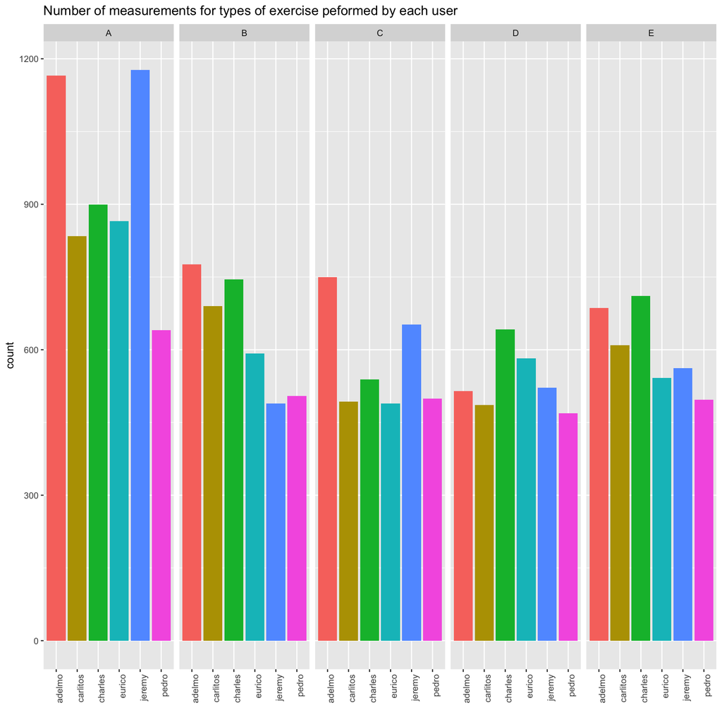

```r
ggplot(training,aes(training$user_name,fill=factor(training$user_name))) + facet_grid(.~ training$classe) + geom_bar() + labs(x="",title="Number of measurements for types of exercise peformed by each user") + theme(legend.position = "none", axis.text.x = element_text(angle = 90, hjust = 1))
```

```r
## List of columns not needed for random forest analysis.
remove <- c("X","raw_timestamp_part_1","raw_timestamp_part_2","cvtd_timestamp",
            "new_window","num_window")

## Remove columns
testing_final <- testing_red[,-match(remove,colnames(testing_red))]
training_final <- training_red[,-match(remove,colnames(training_red))]
training_samp <- training_red[5000:11000,]
```

## Details of Modelling Conducted

- Random Forest prediction using the Caret package in R was the method chosen to determine the type of execution of the exercise.
- Default settings were used which included 3 fold cross validation, number of trees was set at 500
- Accuracy was used to select the optimal model

```r
## Fit a random forest model to the training data
rffit <- train(classe ~.,data=training_samp,method="rf",trControl=fitControl,prox=TRUE)

## Release parallel programming cores
stopCluster(cluster)
registerDoSEQ()
```

Model Accuracy

| mtry | Accuracy | Kappa | AccuracySD | KappaSD |
| --- | --- | --- | --- | --- |
| 2 | 0.9983340 | 0.9967723 | 0.0010400 | 0.0020160 |
| 38 | 1.0000000 | 1.0000000 | 0.0000000 | 0.0000000 |
| 75 | 0.9995002 | 0.9990333 | 0.0004998 | 0.0009671 |

Confusion Matrix

|  | A | B | C | class.error |
| --- | --- | --- | --- | --- |
| A | 581 | 0 | 0 | 0 |
| B | 0 | 3797 | 0 | 0 |
| C | 0 | 0 | 1623 | 0 |

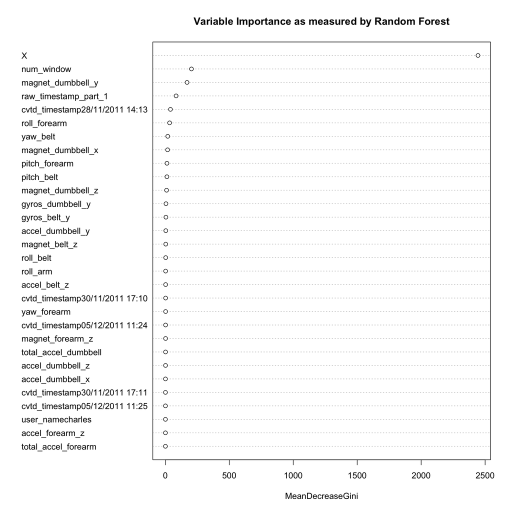